# Chapter 6 notebook

# Exercises based on Vandermeer and Goldberg

**Due 09 April 2018**

This Notebook will help familiarize you with the different types of qualitative dynamics of mostly predator-prey and consumer-resource models, but also a few others. Essentially, I am asking you to make a time series, a phase plane, and find the nullclines for different models. Although we are just learning them in week 7, we will be studying them in more depth weeks 8 through 10.

### 6A

#### Neutralism

Plot a time series, phase plane, and describe the 4 nullclines for a case of neutralism.

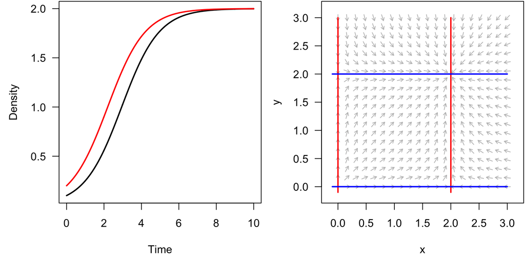

```r
neut <- function(t, y, parameters) {
  N1 <- y[1]
  N2 <- y[2]
  dN1 <- 1*N1 - 0.5*N1*N1
  dN2 <- 1*N2 - 0.5*N2*N2
  return(list(c(dN1, dN2)))
}

runtimes <- seq(from = 0, to = 10, by = 0.01)
init.dens <- c(N1 = 0.1, N2 = 0.2)

par(mar = c(4.5, 4.5, 0.1, 0.1), mfrow = c(1, 2))
neut.out <- ode(y = init.dens, parms = NULL, func = neut, times = runtimes)
plot(x = neut.out[,1], y = neut.out[,2], type = "l", lwd = 2, xlab = "Time", ylab = "Density", las = 1)
  lines(x = neut.out[,1], y = neut.out[,3], lwd = 2, col = "red")

a <- flowField(deriv = neut, x.lim = c(0, 3), y.lim = c(0, 3), parameters = NULL, add = F, points = 20, las = 1)
a <- nullclines(deriv = neut, x.lim = c(-.1, 3), y.lim = c(-.1, 3), parameters = NULL, lwd = 2)
```

The nullclines for species 1 are: $N_1^* = 0$ and $N_1^* = \frac{r_1}{\alpha _1}$. The nullclines for species 2 are: $N_2^* = 0$ and $N_2^* = \frac{r_2}{\alpha _2}$

### 6B

#### Amensalism

Plot a time series, phase plane, and describe the 4 nullclines for a case of amensalism.

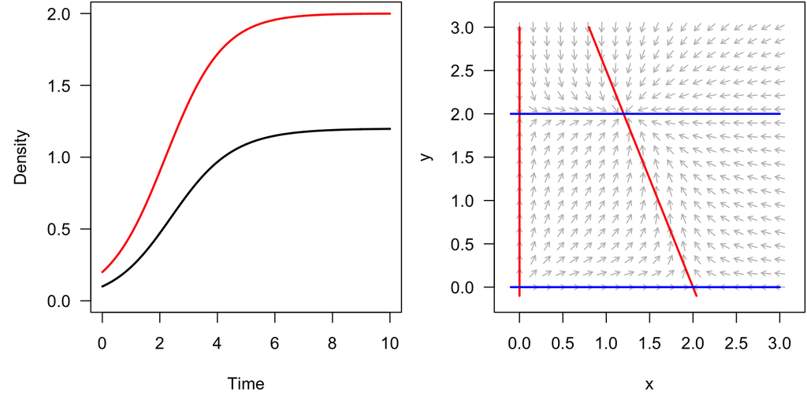

```r
amen <- function(t, y, parameters) {
  N1 <- y[1]
  N2 <- y[2]
  dN1 <- 1*N1 - 0.5*N1*N1 - 0.2*N1*N2
  dN2 <- 1*N2 - 0.5*N2*N2
  return(list(c(dN1, dN2)))
}

runtimes <- seq(from = 0, to = 10, by = 0.01)
init.dens <- c(N1 = 0.1, N2 = 0.2)

par(mar = c(4.5, 4.5, 0.1, 0.1), mfrow = c(1, 2))
amen.out <- ode(y = init.dens, parms = NULL, func = amen, times = runtimes)
plot(x = amen.out[,1], y = amen.out[,2], type = "l", lwd = 2, xlab = "Time", ylab = "Density", las = 1, ylim = c(0, 2))
  lines(x = amen.out[,1], y = amen.out[,3], lwd = 2, col = "red")

a <- flowField(deriv = amen, x.lim = c(0, 3), y.lim = c(0, 3), parameters = NULL, add = F, points = 20, las = 1)
a <- nullclines(deriv = amen, x.lim = c(-.1, 3), y.lim = c(-.1, 3), parameters = NULL, lwd = 2)
```

The nullclines for species 1 are: $N_1^* = 0$ and $N_1^* = \frac{r_1 - \beta _1N_2}{\alpha _1}$. The nullclines for species 2 are: $N_2^* = 0$ and $N_2^* = \frac{r_2}{\alpha _2}$

### 6C

#### Comensalism

Plot a time series, phase plane, and describe the 4 nullclines for a case of Comensalism.

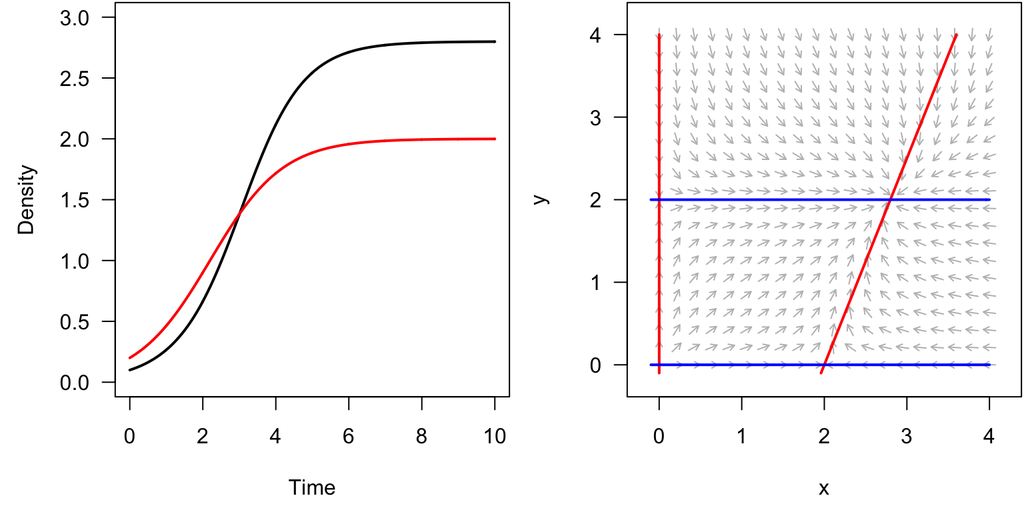

```r
comm <- function(t, y, parameters) {
  N1 <- y[1]
  N2 <- y[2]
  dN1 <- 1*N1 - 0.5*N1*N1 + 0.2*N1*N2
  dN2 <- 1*N2 - 0.5*N2*N2
  return(list(c(dN1, dN2)))
}

runtimes <- seq(from = 0, to = 10, by = 0.01)
init.dens <- c(N1 = 0.1, N2 = 0.2)

par(mar = c(4.5, 4.5, 0.1, 0.1), mfrow = c(1, 2))
comm.out <- ode(y = init.dens, parms = NULL, func = comm, times = runtimes)
plot(x = comm.out[,1], y = comm.out[,2], type = "l", lwd = 2, xlab = "Time", ylab = "Density", las = 1, ylim = c(0, 3))
  lines(x = comm.out[,1], y = comm.out[,3], lwd = 2, col = "red")

a <- flowField(deriv = comm, x.lim = c(0, 4), y.lim = c(0, 4), parameters = NULL, add = F, points = 20, las = 1)
a <- nullclines(deriv = comm, x.lim = c(-.1, 4), y.lim = c(-.1, 4), parameters = NULL, lwd = 2)
```

The nullclines for species 1 are: $N_1^* = 0$ and $N_1^* = \frac{r_1 + \beta _1N_2}{\alpha _1}$. The nullclines for species 2 are: $N_2^* = 0$ and $N_2^* = \frac{r_2}{\alpha _2}$

### 6D

#### Predator-prey/consumer-resource, I

Plot a time series, phase plane, and describe the 4 nullclines for a predator-prey model where each species is govererned by logistic dynamics (i.e., an extension of the above).

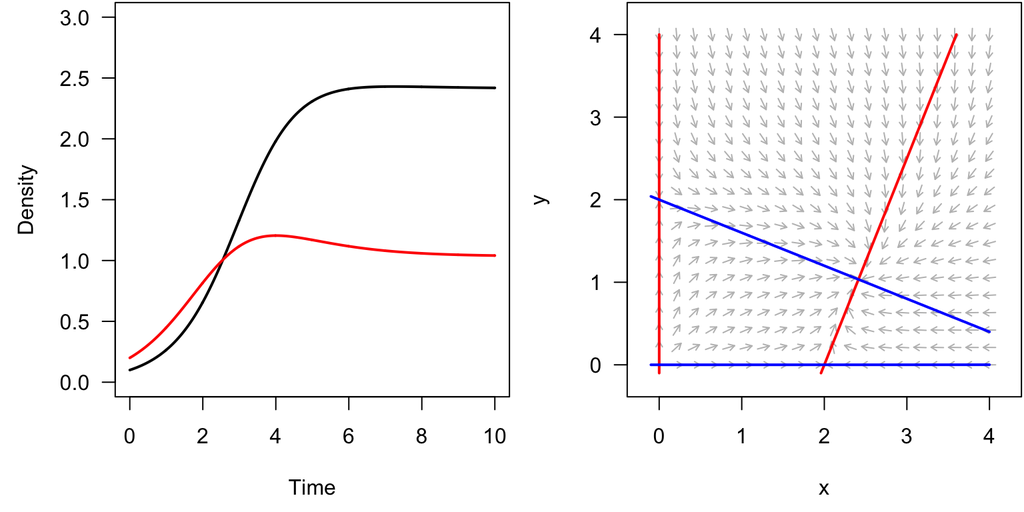

```r
pp.log <- function(t, y, parameters) {
  N1 <- y[1]
  N2 <- y[2]
  dN1 <- 1*N1 - 0.5*N1*N1 + 0.2*N1*N2
  dN2 <- 1*N2 - 0.5*N2*N2 - 0.2*N1*N2
  return(list(c(dN1, dN2)))
}

runtimes <- seq(from = 0, to = 10, by = 0.01)
init.dens <- c(N1 = 0.1, N2 = 0.2)

par(mar = c(4.5, 4.5, 0.1, 0.1), mfrow = c(1, 2))
pp.log.out <- ode(y = init.dens, parms = NULL, func = pp.log, times = runtimes)
plot(x = pp.log.out[,1], y = pp.log.out[,2], type = "l", lwd = 2, xlab = "Time", ylab = "Density", las = 1, ylim = c(0, 3))
  lines(x = pp.log.out[,1], y = pp.log.out[,3], lwd = 2, col = "red")

a <- flowField(deriv = pp.log, x.lim = c(0, 4), y.lim = c(0, 4), parameters = NULL, add = F, points = 20, las = 1)
a <- nullclines(deriv = pp.log, x.lim = c(-.1, 4), y.lim = c(-.1, 4), parameters = NULL, lwd = 2)
```

The nullclines for species 1 are: $N_1^* = 0$ and $N_1^* = \frac{r_1 + \beta _1 N_2}{\alpha _1}$. The nullclines for species 2 are: $N_2^* = 0$ and $N_2^* = \frac{r_2 - \beta _2N_1}{\alpha _2}$

### 6E

#### Predator-prey/consumer-resource, II

Plot a time series, phase plane, and describe the 4 nullclines for a predator-prey model where prey grow exponentially and predators die constantly (i.e., equation 3 from V&G).

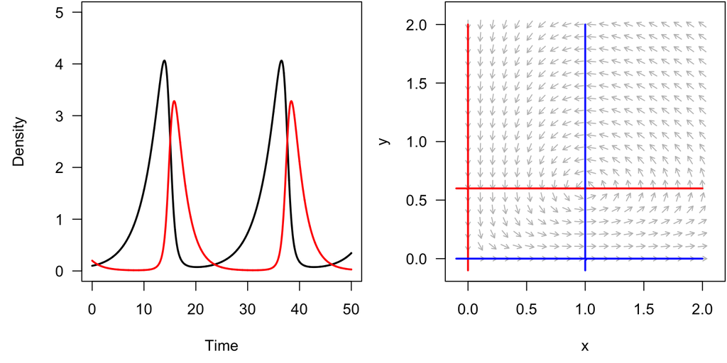

```r
pp.excon <- function(t, y, parameters) {
  N1 <- y[1]
  N2 <- y[2]
  dN1 <- 0.3*N1 - 0.5*N1*N2
  dN2 <- 0.5*N1*N2 - 0.5*N2
  return(list(c(dN1, dN2)))
}

runtimes <- seq(from = 0, to = 50, by = 0.01)
init.dens <- c(N1 = 0.1, N2 = 0.2)

par(mar = c(4.5, 4.5, 0.1, 0.1), mfrow = c(1, 2))
pp.excon.out <- ode(y = init.dens, parms = NULL, func = pp.excon, times = runtimes)
plot(x = pp.excon.out[,1], y = pp.excon.out[,2], type = "l", lwd = 2, xlab = "Time", ylab = "Density", las = 1, ylim = c(0, 5))
  lines(x = pp.excon.out[,1], y = pp.excon.out[,3], lwd = 2, col = "red")

a <- flowField(deriv = pp.excon, x.lim = c(0, 2), y.lim = c(0, 2), parameters = NULL, add = F, points = 20, las = 1)
a <- nullclines(deriv = pp.excon, x.lim = c(-.1, 2), y.lim = c(-.1, 2), parameters = NULL, lwd = 2)
```

The nullclines for species 1 are: $N_1^* = 0$ and $N_2^* = \frac{r}{\beta}$. The nullclines for species 2 are: $N_2^* = 0$ and $N_1^* = \frac{m}{\beta}$

### 6F

#### Predator-prey/consumer-resource, III

Plot a time series, phase plane, and describe the 4 nullclines for a predator-prey model where prey grow logistically and predators die constantly (i.e., equation 6 from V&G).

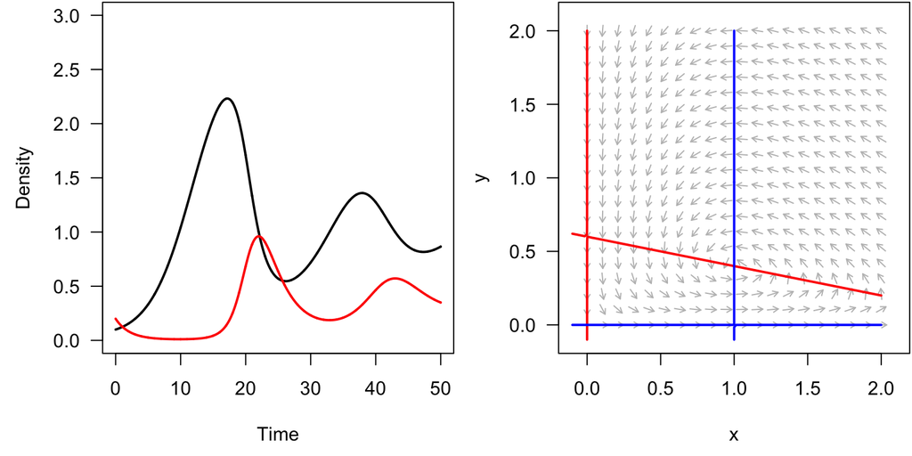

```r
pp.logcon <- function(t, y, parameters) {
  N1 <- y[1]
  N2 <- y[2]
  dN1 <- 0.3*N1 - 0.1*N1*N1 - 0.5*N1*N2
  dN2 <- 0.5*N1*N2 - 0.5*N2
  return(list(c(dN1, dN2)))
}

runtimes <- seq(from = 0, to = 50, by = 0.01)
init.dens <- c(N1 = 0.1, N2 = 0.2)

par(mar = c(4.5, 4.5, 0.1, 0.1), mfrow = c(1, 2))
pp.logcon.out <- ode(y = init.dens, parms = NULL, func = pp.logcon, times = runtimes)
plot(x = pp.logcon.out[,1], y = pp.logcon.out[,2], type = "l", lwd = 2, xlab = "Time", ylab = "Density", las = 1, ylim = c(0, 3))
  lines(x = pp.logcon.out[,1], y = pp.logcon.out[,3], lwd = 2, col = "red")

a <- flowField(deriv = pp.logcon, x.lim = c(0, 2), y.lim = c(0, 2), parameters = NULL, add = F, points = 20, las = 1)
a <- nullclines(deriv = pp.logcon, x.lim = c(-.1, 2), y.lim = c(-.1, 2), parameters = NULL, lwd = 2)
```

The nullclines for species 1 are: $N_1^* = 0$ and $N_1^* = \frac{r - \beta N_2}{\alpha _1}$. The nullclines for species 2 are: $N_2^* = 0$ and $N_1^* = \frac{m}{\beta}$